# Telco_Churn_EDA_Prediction

### Introduction

The Goal of this exercise is to understand the Telco Data From [here](https://www.kaggle.com/blastchar/telco-customer-churn). </br> How are various factors correlated to each other and the churn value.</br> Analyse what are the factors that are diriving the Churn. </br> Can we predict a customer churn</br>

Let's start by loading libaries and the reading the data and setting up some environment values

```python
import os
import sys
import pandas as pd
import numpy as np
import datetime
import math
import scipy.stats as stats
import seaborn as sns
from matplotlib import pyplot as plt
import phik
from phik.report import plot_correlation_matrix
from phik import report
import scipy.stats as ss
import scipy.cluster.hierarchy as sch
from collections import Counter
from sklearn.preprocessing import MinMaxScaler
from sklearn.preprocessing import LabelEncoder
from sklearn.model_selection import train_test_split
from sklearn.neighbors import KNeighborsClassifier
from sklearn.naive_bayes import GaussianNB
from sklearn.linear_model import LogisticRegression
from sklearn.tree import DecisionTreeClassifier
from sklearn.ensemble import RandomForestClassifier
from sklearn.model_selection import train_test_split
from sklearn.preprocessing import LabelEncoder
from sklearn.ensemble import AdaBoostClassifier
from sklearn.model_selection import GridSearchCV
from sklearn.metrics import accuracy_score, confusion_matrix, classification_report


%matplotlib inline
```

```python
pd.set_option('display.max_columns', 500)
```

```python
raw_data = os.path.join('..', 'data', 'WA_Fn-UseC_-Telco-Customer-Churn.csv')
```

```python
df_raw_data = pd.read_csv(raw_data)
```

```python
df_raw_data.head()
```

|  | customerID | gender | SeniorCitizen | Partner | Dependents | tenure | PhoneService | MultipleLines | InternetService | OnlineSecurity | OnlineBackup | DeviceProtection | TechSupport | StreamingTV | StreamingMovies | Contract | PaperlessBilling | PaymentMethod | MonthlyCharges | TotalCharges | Churn |
| --- | --- | --- | --- | --- | --- | --- | --- | --- | --- | --- | --- | --- | --- | --- | --- | --- | --- | --- | --- | --- | --- |
| 0 | 7590-VHVEG | Female | 0 | Yes | No | 1 | No | No phone service | DSL | No | Yes | No | No | No | No | Month-to-month | Yes | Electronic check | 29.85 | 29.85 | No |
| 1 | 5575-GNVDE | Male | 0 | No | No | 34 | Yes | No | DSL | Yes | No | Yes | No | No | No | One year | No | Mailed check | 56.95 | 1889.5 | No |
| 2 | 3668-QPYBK | Male | 0 | No | No | 2 | Yes | No | DSL | Yes | Yes | No | No | No | No | Month-to-month | Yes | Mailed check | 53.85 | 108.15 | Yes |
| 3 | 7795-CFOCW | Male | 0 | No | No | 45 | No | No phone service | DSL | Yes | No | Yes | Yes | No | No | One year | No | Bank transfer (automatic) | 42.30 | 1840.75 | No |
| 4 | 9237-HQITU | Female | 0 | No | No | 2 | Yes | No | Fiber optic | No | No | No | No | No | No | Month-to-month | Yes | Electronic check | 70.70 | 151.65 | Yes |

```python
len(df_raw_data)
```

```
7043
```

```python
df_raw_data.columns
```

```
Index(['customerID', 'gender', 'SeniorCitizen', 'Partner', 'Dependents',
       'tenure', 'PhoneService', 'MultipleLines', 'InternetService',
       'OnlineSecurity', 'OnlineBackup', 'DeviceProtection', 'TechSupport',
       'StreamingTV', 'StreamingMovies', 'Contract', 'PaperlessBilling',
       'PaymentMethod', 'MonthlyCharges', 'TotalCharges', 'Churn'],
      dtype='object')
```

Some Interesting Points to Note -

- Their are 7043 data points
- We have a fair bit of values avaialbe. Looks like these are services that a customer subscribes to
- customerID seems to be the unique identifier in this data
- There is no date/time feature, as per our requirement we'll have to create one

Let's start with creating a time feature

Since we can divide the data into 3 months since june. Let's split based on weeks

```python
def add_date(idx):
    val = math.floor(idx/541)

    u = datetime.datetime.strptime("2021-06-05","%Y-%m-%d")
    d = datetime.timedelta(days=7*val)
    return u + d
```

```python
df_raw_data['RecordDate'] = df_raw_data.index.map(add_date)
```

```python
df_raw_data.head()
```

|  | customerID | gender | SeniorCitizen | Partner | Dependents | tenure | PhoneService | MultipleLines | InternetService | OnlineSecurity | OnlineBackup | DeviceProtection | TechSupport | StreamingTV | StreamingMovies | Contract | PaperlessBilling | PaymentMethod | MonthlyCharges | TotalCharges | Churn | RecordDate |
| --- | --- | --- | --- | --- | --- | --- | --- | --- | --- | --- | --- | --- | --- | --- | --- | --- | --- | --- | --- | --- | --- | --- |
| 0 | 7590-VHVEG | Female | 0 | Yes | No | 1 | No | No phone service | DSL | No | Yes | No | No | No | No | Month-to-month | Yes | Electronic check | 29.85 | 29.85 | No | 2021-06-05 |
| 1 | 5575-GNVDE | Male | 0 | No | No | 34 | Yes | No | DSL | Yes | No | Yes | No | No | No | One year | No | Mailed check | 56.95 | 1889.5 | No | 2021-06-05 |
| 2 | 3668-QPYBK | Male | 0 | No | No | 2 | Yes | No | DSL | Yes | Yes | No | No | No | No | Month-to-month | Yes | Mailed check | 53.85 | 108.15 | Yes | 2021-06-05 |
| 3 | 7795-CFOCW | Male | 0 | No | No | 45 | No | No phone service | DSL | Yes | No | Yes | Yes | No | No | One year | No | Bank transfer (automatic) | 42.30 | 1840.75 | No | 2021-06-05 |
| 4 | 9237-HQITU | Female | 0 | No | No | 2 | Yes | No | Fiber optic | No | No | No | No | No | No | Month-to-month | Yes | Electronic check | 70.70 | 151.65 | Yes | 2021-06-05 |

```python
len(df_raw_data['RecordDate'].unique())
```

```
14
```

```python
raw_dates_data = os.path.join('..', 'data', 'telco_customer_churn_enhanved.csv')
df_raw_data.to_csv(raw_dates_data, index=False)
```

^^ just saved the incremental data that is created

Let's analyse how each of the variables data is

```python
for i in df_raw_data.columns:
    if i != 'customerID':
        print(f"Unique values in {i}:\n",df_raw_data[i].unique())
```

```
Unique values in gender:
 ['Female' 'Male']
Unique values in SeniorCitizen:
 [0 1]
Unique values in Partner:
 ['Yes' 'No']
Unique values in Dependents:
 ['No' 'Yes']
Unique values in tenure:
 [ 1 34  2 45  8 22 10 28 62 13 16 58 49 25 69 52 71 21 12 30 47 72 17 27
  5 46 11 70 63 43 15 60 18 66  9  3 31 50 64 56  7 42 35 48 29 65 38 68
 32 55 37 36 41  6  4 33 67 23 57 61 14 20 53 40 59 24 44 19 54 51 26  0
 39]
Unique values in PhoneService:
 ['No' 'Yes']
Unique values in MultipleLines:
 ['No phone service' 'No' 'Yes']
Unique values in InternetService:
 ['DSL' 'Fiber optic' 'No']
Unique values in OnlineSecurity:
 ['No' 'Yes' 'No internet service']
Unique values in OnlineBackup:
 ['Yes' 'No' 'No internet service']
Unique values in DeviceProtection:
 ['No' 'Yes' 'No internet service']
Unique values in TechSupport:
 ['No' 'Yes' 'No internet service']
Unique values in StreamingTV:
 ['No' 'Yes' 'No internet service']
Unique values in StreamingMovies:
 ['No' 'Yes' 'No internet service']
Unique values in Contract:
 ['Month-to-month' 'One year' 'Two year']
Unique values in PaperlessBilling:
 ['Yes' 'No']
Unique values in PaymentMethod:
 ['Electronic check' 'Mailed check' 'Bank transfer (automatic)'
 'Credit card (automatic)']
Unique values in MonthlyCharges:
 [29.85 56.95 53.85 ... 63.1  44.2  78.7 ]
Unique values in TotalCharges:
 ['29.85' '1889.5' '108.15' ... '346.45' '306.6' '6844.5']
Unique values in Churn:
 ['No' 'Yes']
Unique values in RecordDate:
 ['2021-06-05T00:00:00.000000000' '2021-06-12T00:00:00.000000000'
 '2021-06-19T00:00:00.000000000' '2021-06-26T00:00:00.000000000'
 '2021-07-03T00:00:00.000000000' '2021-07-10T00:00:00.000000000'
 '2021-07-17T00:00:00.000000000' '2021-07-24T00:00:00.000000000'
 '2021-07-31T00:00:00.000000000' '2021-08-07T00:00:00.000000000'
 '2021-08-14T00:00:00.000000000' '2021-08-21T00:00:00.000000000'
 '2021-08-28T00:00:00.000000000' '2021-09-04T00:00:00.000000000']
```

Most of the varaibles seem to be catagorical in nature

Also seems like most of variable DO NOT have any missing/Null Data. This is good, as would require less cleaning

```python
catagorical_features = ['gender',  'SeniorCitizen', 'Partner', 'Dependents', 'PhoneService', 'MultipleLines', 'InternetService',
       'OnlineSecurity', 'OnlineBackup', 'DeviceProtection', 'TechSupport',
       'StreamingTV', 'StreamingMovies', 'Contract', 'PaperlessBilling',
       'PaymentMethod']
```

Let's start with exploring Continues variables first

[output not shown]

```python
df_raw_data['TotalCharges'].describe()
```

```
count     7043
unique    6531
top       20.2
freq        11
Name: TotalCharges, dtype: object
```

Surprisignly Total Charges isn't a float column. Converting it to float for better analysis

```python
df_raw_data['TotalCharges'] = pd.to_numeric(df_raw_data['TotalCharges'],errors='coerce')
```

since only 11 rows are 'nan'. we can drop those for now

```python
df_raw_data = df_raw_data.dropna()
```

```python
df_raw_data['MonthlyCharges'].describe()
```

```
count    7032.000000
mean       64.798208
std        30.085974
min        18.250000
25%        35.587500
50%        70.350000
75%        89.862500
max       118.750000
Name: MonthlyCharges, dtype: float64
```

```python
df_raw_data['TotalCharges'].describe()
```

```
count    7032.000000
mean     2283.300441
std      2266.771362
min        18.800000
25%       401.450000
50%      1397.475000
75%      3794.737500
max      8684.800000
Name: TotalCharges, dtype: float64
```

```python
df_raw_data['tenure'].describe()
```

```
count    7032.000000
mean       32.421786
std        24.545260
min         1.000000
25%         9.000000
50%        29.000000
75%        55.000000
max        72.000000
Name: tenure, dtype: float64
```

Let's Start with Count plots of catagorical features

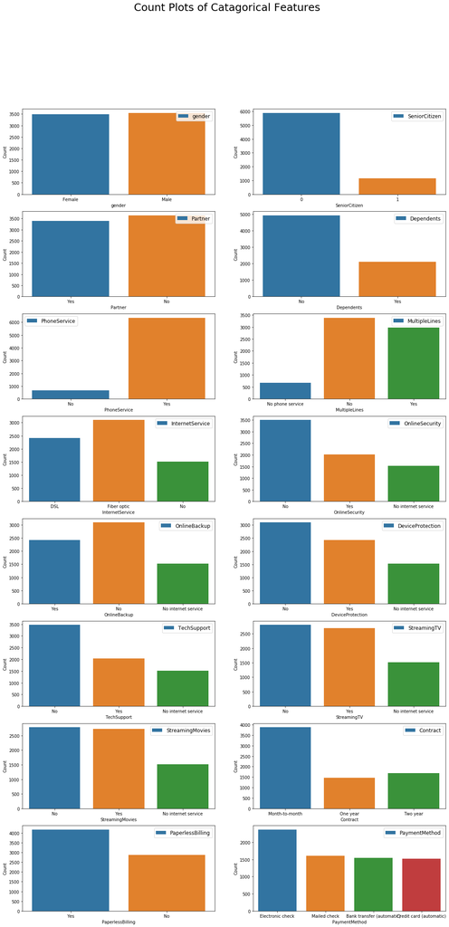

```python
n_rows, n_cols = (8, 2)
figure, axes = plt.subplots(nrows=n_rows, ncols=n_cols,figsize=(18, 35))
figure.suptitle('Count Plots of Catagorical Features', fontsize=25)
for index, column in enumerate(catagorical_features):
    try:
        i,j = (index // n_cols), (index % n_cols)
        fig=sns.countplot(df_raw_data[column], label=column,
        ax=axes[i,j])
        fig=fig.legend(loc='best', fontsize=12)
        axes[i,j].set_ylabel("Count",fontsize='medium')
    except Exception:
        print(column)

        raise
plt.show()
```

Some insights from this analysis ->

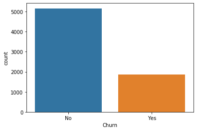

```python
sns.countplot(df_raw_data['Churn'])
```

^^ Looks like we have a highly imbalanced dataset

Now Let's see how some of these catagorical features are divided based on Churn Value

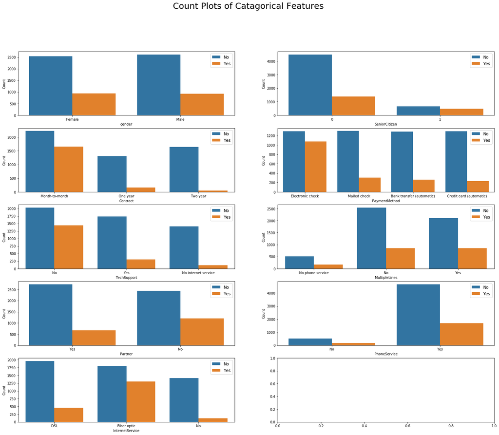

```python
n_rows, n_cols = (5, 2)
figure, axes = plt.subplots(nrows=n_rows, ncols=n_cols,figsize=(25, 20))
figure.suptitle('Count Plots of Catagorical Features', fontsize=25)
for index, column in enumerate(['gender','SeniorCitizen','Contract', 'PaymentMethod','TechSupport','MultipleLines', 'Partner','PhoneService','InternetService']):
    try:
        i,j = (index // n_cols), (index % n_cols)
        fig=sns.countplot(data = df_raw_data, x= column, hue='Churn',
        ax=axes[i,j])
        fig=fig.legend(loc='best', fontsize=12)
        axes[i,j].set_ylabel("Count",fontsize='medium')
    except Exception:
        print(column)

        raise
plt.show()
```

Some Insights -->

Let's now analyse some continues variables

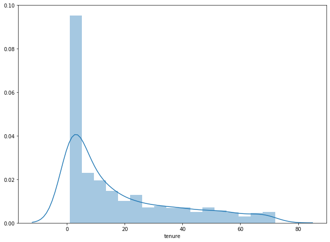

```python
fig, ax = plt.subplots()
fig.set_size_inches(11, 8)
sns.distplot(df_raw_data[df_raw_data['Churn']=='Yes']['tenure'])
```

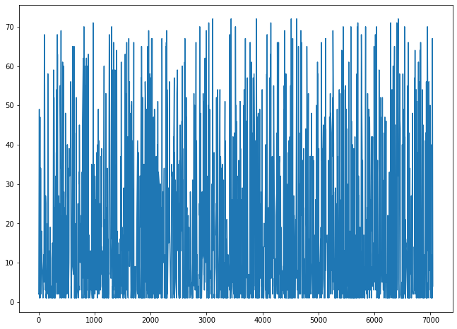

```python
fig, ax = plt.subplots()
fig.set_size_inches(11, 8)
sns.lineplot(data=df_raw_data[df_raw_data['Churn']=='Yes']["tenure"])
```

Let's see corelation between each features

```python
numerical = ['tenure','MonthlyCharges', 'TotalCharges']
```

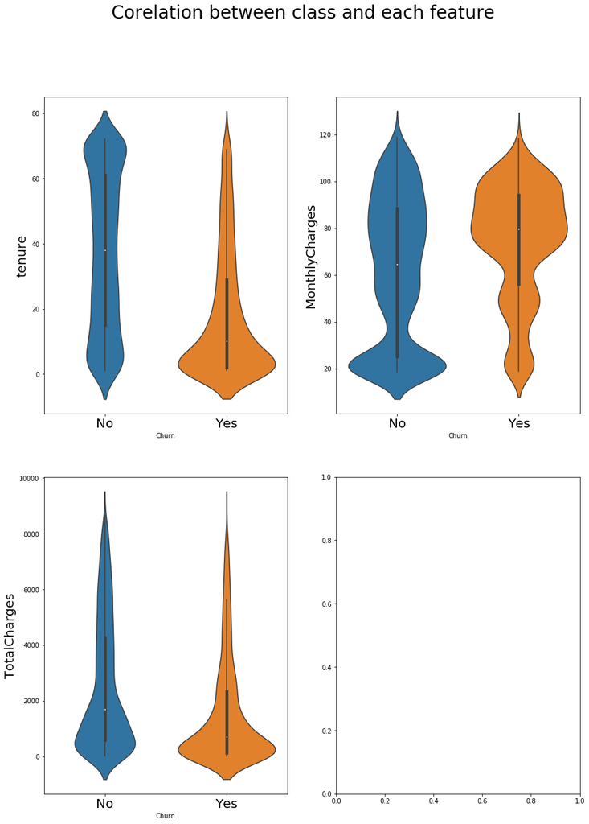

```python
n_rows, n_cols = (2,2)
figure, axes = plt.subplots(nrows=n_rows, ncols=n_cols,figsize=(15, 20))
figure.suptitle('Corelation between class and each feature', fontsize=28)
for index, column in enumerate(numerical):
 i,j = index // n_cols, index % n_cols
 collabel=column
 fig = sns.violinplot(x="Churn", y=column, data=df_raw_data,
 ax=axes[i,j])
 axes[i,j].set_xlabel("Churn")
 axes[i,j].set_ylabel(column,fontsize=20)
 axes[i,j].set_xticklabels(axes[i,j].get_xticklabels(), Fontsize=20)

plt.show()
```

This is really interesting. The distribution for Churn vs Not Churn is very different for Tenure and Monthly Charges.

Let's Analyse it furhter ->

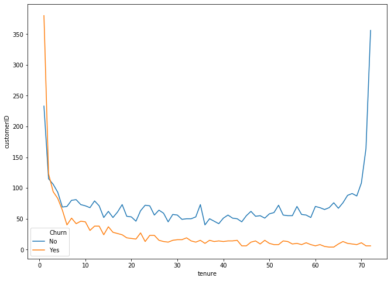

```python
fig, ax = plt.subplots()
fig.set_size_inches(11, 8)
sns.lineplot(data = df_raw_data.groupby(['tenure', 'Churn'], as_index=False)['customerID'].count(), x= 'tenure', y='customerID', hue='Churn')
```

^^Notce how the corelation goes opposite as tenure increses

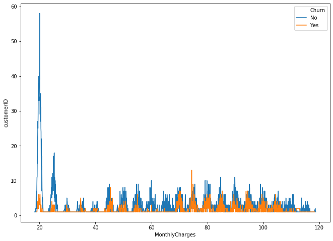

```python
fig, ax = plt.subplots()
fig.set_size_inches(11, 8)
sns.lineplot(data = df_raw_data.groupby(['MonthlyCharges', 'Churn'], as_index=False)['customerID'].count(), x= 'MonthlyCharges', y='customerID', hue='Churn')
```

Seems like lower monthly charge has least churn

Also looks like their are a catagory of customers who are happy to pay more (lack of corelation at 65-70 point)

### Hypothesis->

InternetService, Type of Contract, PaymentMethod, Tenure and Monthly Charges seem to be the most important factors

But before doing final feature slection. we can run top contributing factors from Random Forest as well

Before doing that. Let's do Label Encoding of Catagorical Features and MinMax Sacling of numerical feautures

Create a feature list

Create month based feature as well

```python
labelencoder = LabelEncoder()
df_raw_data['genderN'] = labelencoder.fit_transform(df_raw_data['gender'])
df_raw_data['PartnerN'] = labelencoder.fit_transform(df_raw_data['Partner'])
df_raw_data['DependentsN'] = labelencoder.fit_transform(df_raw_data['Dependents'])
df_raw_data['PhoneServiceN'] = labelencoder.fit_transform(df_raw_data['PhoneService'])
df_raw_data['MultipleLinesN'] = labelencoder.fit_transform(df_raw_data['MultipleLines'])
df_raw_data['InternetServiceN'] = labelencoder.fit_transform(df_raw_data['InternetService'])
df_raw_data['OnlineSecurityN'] = labelencoder.fit_transform(df_raw_data['OnlineSecurity'])
df_raw_data['DeviceProtectionN'] = labelencoder.fit_transform(df_raw_data['DeviceProtection'])
df_raw_data['TechSupportN'] = labelencoder.fit_transform(df_raw_data['TechSupport'])
df_raw_data['StreamingTVN'] = labelencoder.fit_transform(df_raw_data['StreamingTV'])
df_raw_data['StreamingMoviesN'] = labelencoder.fit_transform(df_raw_data['StreamingMovies'])
df_raw_data['ContractN'] = labelencoder.fit_transform(df_raw_data['Contract'])
df_raw_data['PaperlessBillingN'] = labelencoder.fit_transform(df_raw_data['PaperlessBilling'])
df_raw_data['PaymentMethodN'] = labelencoder.fit_transform(df_raw_data['PaymentMethod'])
df_raw_data['ChurnN'] = labelencoder.fit_transform(df_raw_data['Churn'])
```

```python
df_raw_data.head()
```

|  | customerID | gender | SeniorCitizen | Partner | Dependents | tenure | PhoneService | MultipleLines | InternetService | OnlineSecurity | OnlineBackup | DeviceProtection | TechSupport | StreamingTV | StreamingMovies | Contract | PaperlessBilling | PaymentMethod | MonthlyCharges | TotalCharges | Churn | RecordDate | genderN | PartnerN | DependentsN | PhoneServiceN | MultipleLinesN | InternetServiceN | OnlineSecurityN | … |
| --- | --- | --- | --- | --- | --- | --- | --- | --- | --- | --- | --- | --- | --- | --- | --- | --- | --- | --- | --- | --- | --- | --- | --- | --- | --- | --- | --- | --- | --- | --- |
| 0 | 7590-VHVEG | Female | 0 | Yes | No | 1 | No | No phone service | DSL | No | Yes | No | No | No | No | Month-to-month | Yes | Electronic check | 29.85 | 29.85 | No | 2021-06-05 | 0 | 1 | 0 | 0 | 1 | 0 | 0 | … |
| 1 | 5575-GNVDE | Male | 0 | No | No | 34 | Yes | No | DSL | Yes | No | Yes | No | No | No | One year | No | Mailed check | 56.95 | 1889.50 | No | 2021-06-05 | 1 | 0 | 0 | 1 | 0 | 0 | 2 | … |
| 2 | 3668-QPYBK | Male | 0 | No | No | 2 | Yes | No | DSL | Yes | Yes | No | No | No | No | Month-to-month | Yes | Mailed check | 53.85 | 108.15 | Yes | 2021-06-05 | 1 | 0 | 0 | 1 | 0 | 0 | 2 | … |
| 3 | 7795-CFOCW | Male | 0 | No | No | 45 | No | No phone service | DSL | Yes | No | Yes | Yes | No | No | One year | No | Bank transfer (automatic) | 42.30 | 1840.75 | No | 2021-06-05 | 1 | 0 | 0 | 0 | 1 | 0 | 2 | … |
| 4 | 9237-HQITU | Female | 0 | No | No | 2 | Yes | No | Fiber optic | No | No | No | No | No | No | Month-to-month | Yes | Electronic check | 70.70 | 151.65 | Yes | 2021-06-05 | 0 | 0 | 0 | 1 | 0 | 1 | 0 | … |

```python
scalar = MinMaxScaler()
df_raw_data['scaledTenure'] = scalar.fit_transform(df_raw_data[['tenure']])
df_raw_data['scaledMonthlyCharges'] = scalar.fit_transform(df_raw_data[['MonthlyCharges']])
df_raw_data['scaledTotalCharges'] = scalar.fit_transform(df_raw_data[['TotalCharges']])
```

Now that we have numerical catagorical fatures. we can test the corelation between them as well using Cramer'sV

```python
cat_var_conv = ['genderN', 'PartnerN', 'DependentsN', 'PhoneServiceN', 'MultipleLinesN', 'InternetServiceN', 'OnlineSecurityN', 'DeviceProtectionN', 'TechSupportN', 'StreamingTVN', 'StreamingMoviesN', 'ContractN', 'PaperlessBillingN', 'PaymentMethodN', 'ChurnN']
```

```python
def cramers_v(x, y):
    confusion_matrix = pd.crosstab(x,y)
    chi2 = ss.chi2_contingency(confusion_matrix)[0]
    n = confusion_matrix.sum().sum()
    phi2 = chi2/n
    r,k = confusion_matrix.shape
    phi2corr = max(0, phi2-((k-1)*(r-1))/(n-1))
    rcorr = r-((r-1)**2)/(n-1)
    kcorr = k-((k-1)**2)/(n-1)
    return np.sqrt(phi2corr/min((kcorr-1),(rcorr-1)))
```

```python
df_raw_data_corr = df_raw_data[cat_var_conv].corr(method = cramers_v)
```

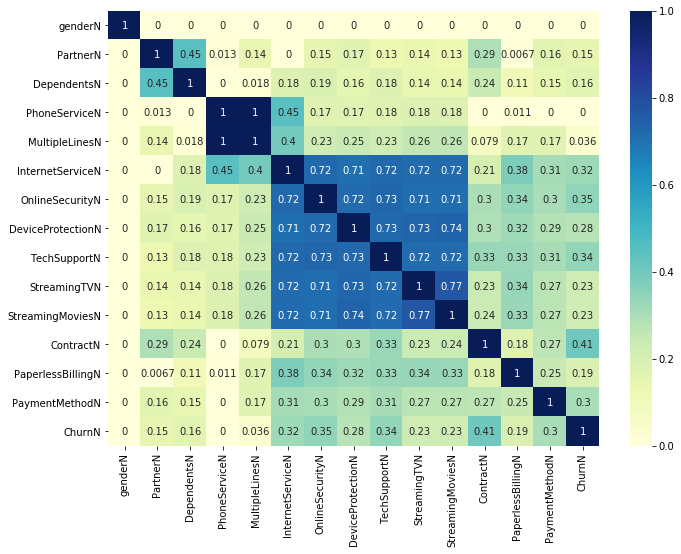

```python
fig, ax = plt.subplots()
fig.set_size_inches(11, 8)
sns.heatmap(df_raw_data_corr, cmap="YlGnBu", annot=True)
```

```python
df_raw_data['month'] = df_raw_data['RecordDate'].dt.month
```

Creating a Long feature list for random forest classifier

```python
feature_list = ['genderN', 'PartnerN', 'DependentsN', 'PhoneServiceN', 'MultipleLinesN', 'InternetServiceN', 'OnlineSecurityN', 'DeviceProtectionN', 'TechSupportN', 'StreamingTVN', 'StreamingMoviesN', 'ContractN', 'PaperlessBillingN', 'PaymentMethodN','month','scaledTenure','scaledMonthlyCharges', 'scaledTotalCharges']
```

```python
 ## tracking the model results in an Dictionary
model_output = {}
```

```python
dependent_attribute = 'ChurnN'
X = df_raw_data[feature_list]
y = df_raw_data[dependent_attribute]
X_train, X_test, y_train, y_test = train_test_split(X, y, test_size = 0.30, random_state = 83)
```

RandomForestClassifier

```python
rd_metrics = {}
rd_clf = RandomForestClassifier(criterion = 'entropy', max_depth = 11, max_features = 'auto',
                                min_samples_leaf = 2, min_samples_split = 3, n_estimators = 130)
rd_clf.fit(X_train, y_train)
# accuracy score, confusion matrix and classification report of random forest
rd_clf_acc = accuracy_score(y_test, rd_clf.predict(X_test))
print(f"Training Accuracy of Random Forest Classifier is {accuracy_score(y_train, rd_clf.predict(X_train))}")
print(f"Test Accuracy of Random Forest Classifier is {rd_clf_acc} \n")
class_report_rd = classification_report(y_test, rd_clf.predict(X_test), output_dict =True)
print(f"Confusion Matrix :- \n{confusion_matrix(y_test, rd_clf.predict(X_test))}\n")
print(f"Classification Report :- \n {classification_report(y_test, rd_clf.predict(X_test))}")
rd_metrics['accuracy'] = class_report_rd['accuracy']
rd_metrics['precision'] = class_report_rd['weighted avg']['precision']
rd_metrics['recall'] = class_report_rd['weighted avg']['recall']
rd_metrics['f1-score'] = class_report_rd['weighted avg']['f1-score']
model_output['Random_Forest_Classifier'] = rd_metrics
```

```
Training Accuracy of Random Forest Classifier is 0.8986184477854531
Test Accuracy of Random Forest Classifier is 0.7985781990521327

Confusion Matrix :-
[[1412  150]
 [ 275  273]]

Classification Report :-
               precision    recall  f1-score   support

           0       0.84      0.90      0.87      1562
           1       0.65      0.50      0.56       548

    accuracy                           0.80      2110
   macro avg       0.74      0.70      0.72      2110
weighted avg       0.79      0.80      0.79      2110
```

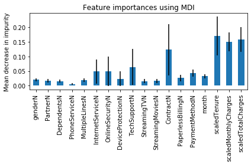

```python
importances = rd_clf.feature_importances_
std = np.std([tree.feature_importances_ for tree in rd_clf.estimators_], axis=0)
forest_importances = pd.Series(importances, index=feature_list)

fig, ax = plt.subplots()
forest_importances.plot.bar(yerr=std, ax=ax)
ax.set_title("Feature importances using MDI")
ax.set_ylabel("Mean decrease in impurity")
fig.tight_layout()
```

Interesting output that even total charges seem to be one of the most contributing factors

let's create a combined new feature list

```python
features=["InternetServiceN", "month", "ContractN", "PaymentMethodN", "scaledTenure", "scaledMonthlyCharges"]
```

```python
dependent_attribute = 'ChurnN'
X = df_raw_data[features]
y = df_raw_data[dependent_attribute]
X_train, X_test, y_train, y_test = train_test_split(X, y, test_size = 0.30, random_state = 83)
```

#### Model Exploration

We can explore following models for this predictive activity -

Naive Bayes

- Good to explore one of classic models, Many times the classics work the best, esp on small dataset we have like right now

kNN (K Nearest Neighbour)

- kNN seem to work for Churn prediction usually

Decision Tree Classifier

- Since we have a lot of features. Tree based algorithms generally work quite good with lots of featurers

Random Forest Classifier

- Since we have a lot of features and we can play aroung with the depth of trees, it is worth exploring the random forest classifier as well. One caution for Random forest is that since we have less data. this model would be prone to overfitting

Starting with Naive Bayes

```python
Naive_Bayes_Metrics = {}
nb=GaussianNB()
nb.fit(X_train, y_train)
# accuracy score, confusion matrix and classification report of Naive Bayes
nb_acc = accuracy_score(y_test, nb.predict(X_test))
print(f"Training Accuracy of Naive Bayes is {accuracy_score(y_train, nb.predict(X_train))}")
print(f"Test Accuracy of Naive Bayes is {nb_acc} \n")
class_report_nb = classification_report(y_test, nb.predict(X_test), output_dict =True)
print(f"Confusion Matrix :- \n{confusion_matrix(y_test, nb.predict(X_test))}\n")
print(f"Classification Report :- \n {classification_report(y_test, nb.predict(X_test))}")
Naive_Bayes_Metrics['accuracy'] = class_report_nb['accuracy']
Naive_Bayes_Metrics['precision'] = class_report_nb['weighted avg']['precision']
Naive_Bayes_Metrics['recall'] = class_report_nb['weighted avg']['recall']
Naive_Bayes_Metrics['f1-score'] = class_report_nb['weighted avg']['f1-score']
model_output['Naive_Bayes'] = Naive_Bayes_Metrics
```

```
Training Accuracy of Naive Bayes is 0.7480698902885006
Test Accuracy of Naive Bayes is 0.7407582938388626

Confusion Matrix :-
[[1162  400]
 [ 147  401]]

Classification Report :-
               precision    recall  f1-score   support

           0       0.89      0.74      0.81      1562
           1       0.50      0.73      0.59       548

    accuracy                           0.74      2110
   macro avg       0.69      0.74      0.70      2110
weighted avg       0.79      0.74      0.75      2110
```

```python
knn_metrics = {}
knn = KNeighborsClassifier()
knn.fit(X_train, y_train)
# accuracy score, confusion matrix and classification report of knn
knn_acc = accuracy_score(y_test, knn.predict(X_test))
print(f"Training Accuracy of KNN is {accuracy_score(y_train, knn.predict(X_train))}")
print(f"Test Accuracy of KNN is {knn_acc} \n")
class_report_knn = classification_report(y_test, knn.predict(X_test), output_dict =True)
print(f"Confusion Matrix :- \n{confusion_matrix(y_test, knn.predict(X_test))}\n")
print(f"Classification Report :- \n {classification_report(y_test, knn.predict(X_test))}")
knn_metrics['accuracy'] = class_report_knn['accuracy']
knn_metrics['precision'] = class_report_knn['weighted avg']['precision']
knn_metrics['recall'] = class_report_knn['weighted avg']['recall']
knn_metrics['f1-score'] = class_report_knn['weighted avg']['f1-score']
model_output['KNN'] = knn_metrics
```

```
Training Accuracy of KNN is 0.8380739536773669
Test Accuracy of KNN is 0.7706161137440758

Confusion Matrix :-
[[1347  215]
 [ 269  279]]

Classification Report :-
               precision    recall  f1-score   support

           0       0.83      0.86      0.85      1562
           1       0.56      0.51      0.54       548

    accuracy                           0.77      2110
   macro avg       0.70      0.69      0.69      2110
weighted avg       0.76      0.77      0.77      2110
```

```python
dtc_metrics = {}
dtc = DecisionTreeClassifier()
dtc.fit(X_train, y_train)
# accuracy score, confusion matrix and classification report of decision tree
dtc_acc = accuracy_score(y_test, dtc.predict(X_test))
print(f"Training Accuracy of Decision Tree Classifier is {accuracy_score(y_train, dtc.predict(X_train))}")
print(f"Test Accuracy of Decision Tree Classifier is {dtc_acc} \n")
class_report_dtc = classification_report(y_test, dtc.predict(X_test), output_dict =True)
print(f"Confusion Matrix :- \n{confusion_matrix(y_test, dtc.predict(X_test))}\n")
print(f"Classification Report :- \n {classification_report(y_test, dtc.predict(X_test))}")
dtc_metrics['accuracy'] = class_report_dtc['accuracy']
dtc_metrics['precision'] = class_report_dtc['weighted avg']['precision']
dtc_metrics['recall'] = class_report_dtc['weighted avg']['recall']
dtc_metrics['f1-score'] = class_report_dtc['weighted avg']['f1-score']
model_output['Decision_Tree_Classfier'] = dtc_metrics
```

```
Training Accuracy of Decision Tree Classifier is 0.9969524583502641
Test Accuracy of Decision Tree Classifier is 0.7137440758293839

Confusion Matrix :-
[[1241  321]
 [ 283  265]]

Classification Report :-
               precision    recall  f1-score   support

           0       0.81      0.79      0.80      1562
           1       0.45      0.48      0.47       548

    accuracy                           0.71      2110
   macro avg       0.63      0.64      0.64      2110
weighted avg       0.72      0.71      0.72      2110
```

```python
rd_metrics = {}
rd_clf = RandomForestClassifier(criterion = 'entropy', max_depth = 11, max_features = 'auto',
                                min_samples_leaf = 2, min_samples_split = 3, n_estimators = 130)
rd_clf.fit(X_train, y_train)
# accuracy score, confusion matrix and classification report of random forest
rd_clf_acc = accuracy_score(y_test, rd_clf.predict(X_test))
print(f"Training Accuracy of Random Forest Classifier is {accuracy_score(y_train, rd_clf.predict(X_train))}")
print(f"Test Accuracy of Random Forest Classifier is {rd_clf_acc} \n")
class_report_rd = classification_report(y_test, rd_clf.predict(X_test), output_dict =True)
print(f"Confusion Matrix :- \n{confusion_matrix(y_test, rd_clf.predict(X_test))}\n")
print(f"Classification Report :- \n {classification_report(y_test, rd_clf.predict(X_test))}")
rd_metrics['accuracy'] = class_report_rd['accuracy']
rd_metrics['precision'] = class_report_rd['weighted avg']['precision']
rd_metrics['recall'] = class_report_rd['weighted avg']['recall']
rd_metrics['f1-score'] = class_report_rd['weighted avg']['f1-score']
model_output['Random_Forest_Classifier'] = rd_metrics
```

```
Training Accuracy of Random Forest Classifier is 0.8673303535148313
Test Accuracy of Random Forest Classifier is 0.7876777251184834

Confusion Matrix :-
[[1392  170]
 [ 278  270]]

Classification Report :-
               precision    recall  f1-score   support

           0       0.83      0.89      0.86      1562
           1       0.61      0.49      0.55       548

    accuracy                           0.79      2110
   macro avg       0.72      0.69      0.70      2110
weighted avg       0.78      0.79      0.78      2110
```

```python
model_output
```

```
{'Random_Forest_Classifier': {'accuracy': 0.7876777251184834,
  'precision': 0.7764223556334122,
  'recall': 0.7876777251184834,
  'f1-score': 0.779620530121013},
 'Naive_Bayes': {'accuracy': 0.7407582938388626,
  'precision': 0.7871707619448368,
  'recall': 0.7407582938388626,
  'f1-score': 0.7536456819223823},
 'KNN': {'accuracy': 0.7706161137440758,
  'precision': 0.7637378374856117,
  'recall': 0.7706161137440758,
  'f1-score': 0.7666212101155574},
 'Decision_Tree_Classfier': {'accuracy': 0.7137440758293839,
  'precision': 0.7202650564988194,
  'recall': 0.7137440758293839,
  'f1-score': 0.7167778197658848}}
```

Since we are predicting churn, We value Accuracy the most. it is okay for some false positives to creep through. As we can run retention campaigns to identified customers

Let's do GridSearcgCV as well over random forest as they seem to have the best accuracy amongst the models evaluated

```python
parameters = {'n_estimators':[150,200,250,300], 'max_depth':[15,20,25,30,35]}
forest = RandomForestClassifier()
clf = GridSearchCV(estimator=forest, param_grid=parameters, n_jobs=-1, cv=5)
clf.fit(X, y)
```

```
GridSearchCV(cv=5, error_score=nan,
             estimator=RandomForestClassifier(bootstrap=True, ccp_alpha=0.0,
                                              class_weight=None,
                                              criterion='gini', max_depth=None,
                                              max_features='auto',
                                              max_leaf_nodes=None,
                                              max_samples=None,
                                              min_impurity_decrease=0.0,
                                              min_impurity_split=None,
                                              min_samples_leaf=1,
                                              min_samples_split=2,
                                              min_weight_fraction_leaf=0.0,
                                              n_estimators=100, n_jobs=None,
                                              oob_score=False,
                                              random_state=None, verbose=0,
                                              warm_start=False),
             iid='deprecated', n_jobs=-1,
             param_grid={'max_depth': [15, 20, 25, 30, 35],
                         'n_estimators': [150, 200, 250, 300]},
             pre_dispatch='2*n_jobs', refit=True, return_train_score=False,
             scoring=None, verbose=0)
```

```python
clf.best_params_
```

```
{'max_depth': 15, 'n_estimators': 200}
```

```python
clf.best_score_
```

```
0.7730336328922346
```

^^ these are the params we will be going with in out application

### Month based Train/test Split

Now we know that we have a decent Model

Let's anlayse how good is it if we split the test data based on month

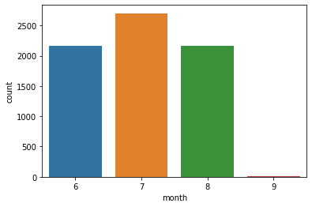

```python
sns.countplot(df_raw_data['month'])
```

Let's try and predict churn values for the month of August

```python
df_train_time = df_raw_data[df_raw_data['month']!=8]
```

```python
df_test_time = df_raw_data[df_raw_data['month']==8]
```

```python
features=["InternetServiceN", "month", "ContractN", "PaymentMethodN", "scaledTenure", "scaledMonthlyCharges"]
dependent_attribute = 'ChurnN'
X = df_train_time[features]
y = df_train_time[dependent_attribute]
```

```python
rd_clf = RandomForestClassifier(max_depth = 15, max_features = 'auto', n_estimators = 200)
rd_clf.fit(X, y)
```

```
RandomForestClassifier(bootstrap=True, ccp_alpha=0.0, class_weight=None,
                       criterion='gini', max_depth=15, max_features='auto',
                       max_leaf_nodes=None, max_samples=None,
                       min_impurity_decrease=0.0, min_impurity_split=None,
                       min_samples_leaf=1, min_samples_split=2,
                       min_weight_fraction_leaf=0.0, n_estimators=200,
                       n_jobs=None, oob_score=False, random_state=None,
                       verbose=0, warm_start=False)
```

```python
rd_clf_acc = accuracy_score(df_test_time[dependent_attribute], rd_clf.predict(df_test_time[features]))
```

```python
rd_clf_acc
```

```
0.7838963442850532
```

### Conclusion

We can see that even with time series split accuracy remains fairly decent

So we have ascenratined our model time series split as well